# Исследование объявлений о продаже квартир

```python
spb_apart_false = spb_apart_false.dropna(subset=['city_centers_nearest']) # Удалим такие значения
```

```python
# Убедимся, что пустые значения в столбце 'city_centers_nearest' отсутствуют
spb_apart_false['city_centers_nearest'].isna().sum()
```

```
0
```

```python
spb_apart_false['rooms'].value_counts() # Ознакомимся с наиболее популярными вариантами предложений
```

```
2    591
1    554
3    470
4    123
5     40
6      5
7      3
0      2
9      1
Name: rooms, dtype: int64
```

Мы видим, что наиболее популярные варианты предложений объектов недвижимости имеют 1, 2, 3 и 4 комнаты. Есть так же 40 объявлений с пятью комнатами, но, так как мы планируем категоризировать данные и по удалённости от центра в Санкт-Петербурге, 40 наблюдений будет для нас мало. Остановимся на 1-, 2-х, 3-х и 4-х комнатных предложениях.

```python
# Создадим список, который будет содержать самые популярные значения количества комнат у объектов недвижимости
# В Санкт-Петербурге

spb_rooms = [1, 2, 3, 4]
```

```python
# Разделим объекты недвижимости Санкт-Петербурга на 4 группы по удалённости от центра.
# За границы примем квартили распределения. Воспользуемся методом describe(), чтобы увидеть их.

spb_apart_false['city_centers_nearest'].describe()
```

```
count     1789.000000
mean     11365.419788
std       4783.832435
min        208.000000
25%       7943.000000
50%      12038.000000
75%      14784.000000
max      28644.000000
Name: city_centers_nearest, dtype: float64
```

```python
# Так как результатом вызова метода describe() является объект типа Series, мы можем написать функцию
# которая будет возвращать список значений квартилей из объекта Series.
def get_quartiles(column):
    first = int(column.describe()[4])
    second = int(column.describe()[5])
    third = int(column.describe()[6])
    return [first, second, third]
```

```python
# Получим список значений квартилей из столбца 'city_centers_nearest'
city_centers_q = get_quartiles(spb_apart_false['city_centers_nearest'])
```

```python
# Убедимся, что функция работает
print(city_centers_q)
```

```
[7943, 12038, 14784]
```

```python
# Чтобы значениями списка city_centers_q можно было пользоваться в цикле, добавим этому списку четвёртый
# элемент, который будет соответствовать максимальному значению из столбца 'city_centers_nearest' отиндексированной
# таблицы df, у которой значения столбца "locality_name" равны строке "Санкт-Петербург"

city_centers_q.append(int(df.query("locality_name == 'Санкт-Петербург'")['city_centers_nearest'].max()))
print(city_centers_q)
```

```
[7943, 12038, 14784, 29493]
```

```python
# На всякий случай проверим, принимает ли столбец 'last_price' отрицательные значения. Не принимает.
df.query('last_price < 0')['last_price'].count()
```

```
0
```

```python
# На основе функции get_quartiles() напишем функцию, которая считает межквартильный размах
# (разницу между третьим и первым квартилем) и вычитает из значения медианы (второго квартиля)
# полтора межквартильных размаха — именно такое значение будем считать пограничным для жилой площади и
# апартаментов

def get_minus_one_and_half_range(column):
    first_q = get_quartiles(column)[0]
    second_q = get_quartiles(column)[1]
    third_q = get_quartiles(column)[2]
    interq_range = third_q - first_q
    point = second_q - 1.5 * interq_range
    if point > 0: # Поскольку значение цены квартиры не может принимать отрицательные значения
        return point  # Функция будет возвращать значение, если оно положительное
    return 0 # В противном случае функция будет возвращать ноль.
```

```python
# Теперь создадим пустой словарь, который заполним с помощью циклов for: ключами этого словаря станет
# количество комнат в объектах недвижимости, а значениями — списки со значениями столбца 'last_price'
# равные значению, полученному в результате вычитания из медианы полутора межквартильных размахов:

# { 1-комнатные: [1-я группа, 2-я группа, 3-я группа, 4-я группа],
#   2-комнатные: [1-я группа, 2-я группа, 3-я группа, 4-я группа],
#   3-комнатные: [1-я группа, 2-я группа, 3-я группа, 4-я группа],
#   4-комнатные: [1-я группа, 2-я группа, 3-я группа, 4-я группа]
# }
#
# Таким образом, если теперь в таблице df, отиндексированной по строкам, в которых значение столбца
# locality_name соответствует Санкт-Петербургу, мы встретим значение цены, которое будет ниже значения первого
# квартиля для указанной группы и количества комнат, будем считать такой объект недвижимости апартаментами.
# Иначе — не будем считать такой объект недвижимости апартаментами.


quart_dict = {}

for i in spb_rooms:
    that_table = spb_apart_false[spb_apart_false['rooms'] == i]
    quart_dict[i] = []
    for j in city_centers_q:
        this_table = that_table[that_table['city_centers_nearest'] <= j]
        first_quart = get_minus_one_and_half_range(this_table['last_price'])
        quart_dict[i].append(first_quart)

print(quart_dict) # Выведем словарь на экран
```

```
{1: [3133401.5, 1272500.0, 1726250.0, 1633625.0], 2: [810803.0, 0, 274577.0, 424250.0], 3: [304809.0, 0, 0, 0], 4: [0, 0, 0, 0]}
```

```python
# Пишем функцию одной строки для замены пропусков в Санкт-Петербурге для 1, 2, 3 и 4-х комнатных квартир
# в столбце 'is_apartment'

def get_spb_apart_values(row):
    city = row['locality_name'] # Переменной city присвоим значение столбца 'locality_name'
    price = row['last_price'] # Переменной price присвоим значение столбца 'last_price'
    distance = row['city_centers_nearest'] # Переменной distanse присвоим значение удалённости от центра
    rooms = row['rooms'] # Переменной rooms присвоим число комнат в объекте недвижимости из столбца 'rooms'
    if city == 'Санкт-Петербург':  # Если значение столбца 'locality_name' равно строке 'Санкт-Петербург'
        for i in spb_rooms:  # Тогда запускаем цикл по значениям количества комнат в наиболее популярных предложениях
            if rooms == i: # Если значение в столбце 'rooms' равно значению переменной цикла
                for j in range(len(city_centers_q)):  # Тогда запускаем цикл по длине списка city_centers_q
                    if distance <= city_centers_q[j]: # Сравниваем значение удалённости от центра со значением
                                                      # верхней границы группы по удалённости
                        if price < quart_dict[i][j]:  # Сравниваем стоимость объекта недвижимости со значением разности
                                                     # медианы и полутора межквартильных размахов, которое соответствует
                                                   # группе недвижимости по удалённости от центра и по количеству комнат
                            return True # И если значение меньше значения разности
                                        # медианы и полутора межквартильных размахов, тогда это апартаменты
                        else:
                            return False # Иначе объект недвижимости не является аппартаментами
    return row['is_apartment'] # Если ни одно из указанных условий неверно, то функция вернёт исходное значение
```

```python
# Посчитаем доли пропусков до применения функции и после
apartment_skips_before = df['is_apartment'].isna().sum()
apartment_skips_part_before = apartment_skips_before / len(df)
print("Количество пропусков в столбце 'is_apartment' в исходных данных:", apartment_skips_before)
print("Что составляет {:.1%} от всех данных".format(apartment_skips_part_before))
```

```
Количество пропусков в столбце 'is_apartment' в исходных данных: 20890
Что составляет 88.3% от всех данных
```

```python
df['is_apartment'] = df.apply(get_spb_apart_values, axis=1) # Применяем функцию к столбцу 'is_apartment'
```

```python
apartment_skips_after = df['is_apartment'].isna().sum()
apartment_skips_part_after = apartment_skips_after / len(df)
difference = apartment_skips_part_before - apartment_skips_part_after
print("Количество пропусков в столбце 'is_apartment' после применения функции:", apartment_skips_after)
print("Что составляет {:.1%} от всех данных".format(apartment_skips_part_after))
print("Мы избавились от {:.1%} пропусков в столбце 'is_apartment'".format(difference))
```

```
Количество пропусков в столбце 'is_apartment' после применения функции: 7586
Что составляет 32.1% от всех данных
Мы избавились от 56.3% пропусков в столбце 'is_apartment'
```

С пропусками для наиболее популярных предложений по числу комнат в Санкт-Петербурге разобрались. Оставшиеся 32.2% пропусков в столбце - это по-прежнему большая доля пропусков. Избавимся от пропусков по Ленинградской области.

```python
# Создадим отдельную переменную для значений с указаниями типа жилплощади не в Санкт-Петербурге
lenobl_apart_false = df_apartment_false.query("locality_name != 'Санкт-Петербург'")
```

```python
# Проверим, есть ли в нашей таблице пропуски в столбце 'city_centers_nearest'
lenobl_apart_false['city_centers_nearest'].isna().sum()

# 611 пропусков в столбце, где должны быть значения удалённости от центра. А сколько записей в нашей таблице?
```

```
611
```

```python
# Проверим длину таблицы
len(lenobl_apart_false)

# Примем как факт, что пропуски в столбце с удалённостью от центра города для объектов недвижимости
# размещённых в Ленинградской области составляют более, чем 2/3 записей. Избавиться от такого количества
# данных мы не можем: это негативно повлияет на точность наших рассчётов. Значит при рассчётах квартилей
# по столбцу со стоимостью будем учитывать только количество комнат. Если в данных имеются выбросы, то
# квартили очень помогут, так как они нечувствительны к выбросам.
```

```
916
```

```python
lenobl_apart_false['rooms'].value_counts() # Ознакомимся с наиболее популярными вариантами предложений

# В Ленобласти популярны предложения недвижимости 1-, 2- и 3-х комнатных квартир. Четырёхкомнатные квартиры
# менее популярны. Так как их меньше 30 в данных таблицы lenobl_apart_false, мы не булем рассчитывать
# по ним необходимые показатели и, соответственно, не будем заменять пропуски в значениях типа жилплощади
# в области для четырёхкомнатных квартир.
```

```
1    348
2    340
3    191
4     25
5      7
0      4
6      1
Name: rooms, dtype: int64
```

```python
# Создадим список, который будет содержать самые популярные значения количества комнат у объектов недвижимости
# В Ленинградской области

lenobl_rooms = [1, 2, 3]
```

```python
# Создадим словарь, в котором ключи будут соответствовать самым популярным значениям количетсва комнат у
# объектов недвижимости Ленобласти, а значения — значениям вычитания полутора межквартильных размахов
# из медианы по столбцу со стоимостью для объектов, разделённых по количеству комнат. После заполнения
# словарь будет иметь такой вид:

# { 1-комнатные: медиана минус полтора межквартиальных размаха],
#   2-комнатные: медиана минус полтора межквартиальных размаха],
#   3-комнатные: медиана минус полтора межквартиальных размаха]
# }

lenobl_quart_dict = {}

for i in lenobl_rooms:
    that_table = lenobl_apart_false[lenobl_apart_false['rooms'] == i]
    lenobl_quart_dict[i] = get_minus_one_and_half_range(that_table['last_price'])

print(lenobl_quart_dict) # Выведем словарь на экран
```

```
{1: 910000.0, 2: 653370.0, 3: 1067500.0}
```

```python
# Пишем функцию одной строки для замены пропусков в Ленобласти для 1, 2, 3-х комнатных квартир
# в столбце 'is_apartment'

def get_lenobl_apart_values(row):
    city = row['locality_name'] # Переменной city присвоим значение столбца 'locality_name'
    price = row['last_price'] # Переменной price присвоим значение столбца 'last_price'
    distance = row['city_centers_nearest'] # Переменной distanse присвоим значение удалённости от центра
    rooms = row['rooms'] # Переменной rooms присвоим число комнат в объекте недвижимости из столбца 'rooms'
    if city != 'Санкт-Петербург': # Если населённый пункт не Санкт-Петербург
        for i in lenobl_rooms:  # Тогда запускаем цикл по значениям количества комнат в наиболее популярных предложениях
            if rooms == i: # Если значение в столбце 'rooms' равно значению переменной цикла
                if price < lenobl_quart_dict[i]: # И если значение в столбце 'last_price' меньше значения разности
                                                 # медианы и полутора межквартильных размахов
                    return True # То это апартаменты
                else:
                    return False # Иначе — это не апартаменты
    return row['is_apartment'] # Если ни одно из указанных условий неверно, то функция вернёт исходное значение
```

```python
# Снова посчитаем доли пропусков до применения функции и после
apartment_skips_before = df['is_apartment'].isna().sum()
apartment_skips_part_before = apartment_skips_before / len(df)
print("Количество пропусков в столбце 'is_apartment' в исходных данных:", apartment_skips_before)
print("Что составляет {:.1%} от всех данных".format(apartment_skips_part_before))
```

```
Количество пропусков в столбце 'is_apartment' в исходных данных: 7586
Что составляет 32.1% от всех данных
```

```python
df['is_apartment'] = df.apply(get_lenobl_apart_values, axis=1) # Применяем функцию к столбцу 'is_apartment'
```

```python
apartment_skips_after = df['is_apartment'].isna().sum()
apartment_skips_part_after = apartment_skips_after / len(df)
difference = apartment_skips_part_before - apartment_skips_part_after
print("Количество пропусков в столбце 'is_apartment' после применения функции:", apartment_skips_after)
print("Что составляет {:.1%} от всех данных".format(apartment_skips_part_after))
print("Мы избавились от {:.1%} пропусков в столбце 'is_apartment'".format(difference))
```

```
Количество пропусков в столбце 'is_apartment' после применения функции: 884
Что составляет 3.7% от всех данных
Мы избавились от 28.3% пропусков в столбце 'is_apartment'
```

Мы заполнили ещё 28.3 % пропусков в столбце 'is_apartment'. Теперь процент пропусков в этом столбце составляет 3.7%. От оставшихся 3.7% можно смело избавиться и, наконец, привести значения столбца 'is_apartment' к типу bool.

```python
df = df.dropna(subset=['is_apartment']) # Удалим строки с пропусками в столбце 'is_apartment'
df['is_apartment'].isna().sum() # Убедимся, что теперь пропусков нет
```

```
0
```

```python
df['is_apartment'] = df['is_apartment'].astype('bool') # Привели значения столбца 'is_apartment' к типу 'bool'
```

```python
df['last_price'] = df['last_price'].astype('int') # Привели значения столбца 'last_price' к типу 'int'
```

```python
df['floors_total'].isna().sum() # Оценим число пропусков в столбце 'floors_total'
```

```
78
```

```python
df = df.dropna(subset=['floors_total']) # Удалим строки с пропусками в столбце 'floors_total', их не много
df['is_apartment'].isna().sum() # Убедимся, что теперь пропусков нет
```

```
0
```

```python
df['floors_total'] = df['floors_total'].astype('int') # Привели значения столбца 'floors_total' к типу 'int'
```

```python
# Приведём столбец 'first_day_exposition' к типу даты и округлим дату до дня методом dt.floor() (к меньшему значению)
df['first_day_exposition'] = pd.to_datetime(df['first_day_exposition'], format='%Y-%m-%dT%H:%M:%S').dt.floor('1D')
```

```python
# Сохраним в отдельной переменной таблицу с пропусками в строках столбца 'days_exposition'
days_exp_nan = df[df['days_exposition'].isna()]
```

```python
# Объявим переменную last_date, в которой сохраним дату последней публикации объявления в базе недвижимости.

last_date = df[df['first_day_exposition'] == df['first_day_exposition'].max()]['first_day_exposition'].reset_index().loc[0, 'first_day_exposition']
type(last_date) # Убедились, что значение переменной имеет нужный нам тип
```

```
pandas._libs.tslibs.timestamps.Timestamp
```

```python
df['days_exposition'] = df['days_exposition'].fillna('NaN') # Заменим пропуски на строку 'NaN', чтобы к такой строке было
# проще обратиться в функции
```

```python
# Создадим функцию одной строки, которая заменит значения столбца 'days_exposition', равные строке 'NaN' на количество дней,
# Которое прошло с даты публикации до даты в переменной last_date.

def get_value_for_days_exp(row):
    if row['days_exposition'] == 'NaN':
        new_value = last_date - row['first_day_exposition']
        new_value = str(new_value)
        new_value = new_value.split(' ')[0]
        return int(new_value)
    return row['days_exposition']
```

```python
# Применили функцию одной строки к столбцу 'days_exposition'

df['days_exposition'] = df.apply(get_value_for_days_exp, axis=1)
```

```python
df['days_exposition'] = df['days_exposition'].astype('int') # Привели значения столбца 'days_exposition' к типу 'int'
```

```python
df['days_exposition'].isna().sum() # Убедились, что в столбце 'days_exposition' больше нет пропусков
```

```
0
```

```python
# В столбце 'rooms' у нас присутствуют значения равные числу 0, но такое значение для количества комнат нелогично.
# Проверим число строк с таким значением

df['rooms'].value_counts()
```

```
1    7986
2    7881
3    5764
4     991
5      49
0       6
6       6
7       4
9       1
Name: rooms, dtype: int64
```

```python
# Таких строк 6, можем удалить их.

df = df[df['rooms'] != 0]
df['rooms'].value_counts() # Убедимся, что числа 0 больше нет среди значений столбца 'rooms'
```

```
1    7986
2    7881
3    5764
4     991
5      49
6       6
7       4
9       1
Name: rooms, dtype: int64
```

```python
df.isna().sum() # Посмотрим на пропуски теперь
```

```
total_images                0
last_price                  0
total_area                  0
first_day_exposition        0
rooms                       0
ceiling_height           8745
floors_total                0
living_area              1780
floor                       0
is_apartment                0
studio                      0
open_plan                   0
kitchen_area             1943
balcony                     0
locality_name               0
airports_nearest         5265
city_centers_nearest     5243
parks_around_3000        5242
parks_nearest           15003
ponds_around_3000        5242
ponds_nearest           14039
days_exposition             0
dtype: int64
```

```python
# Теперь на основе данных, в которых указаны жилая площадь и площадь кухни рассчитаем медианное значение доли от общей площади
# (пропусков в значениях общей площади в наших данных нет) и заменим пропуски в значениях жилой площади и площади кухни,
# умножив общую площадь на соответствующие доли.

df_for_calc = df.dropna(subset=['living_area', 'kitchen_area'])
living_area_part = (df_for_calc['living_area'] / df_for_calc['total_area']).median()
kitchen_area_part = (df_for_calc['kitchen_area'] / df_for_calc['total_area']).median()

print("Медианное значение доли жилой площади от общей площади квартиры составляет {:.1%}".format(living_area_part))
print("Медианное значение доли кухни от общей площади квартиры составляет {:.1%}".format(kitchen_area_part))
```

```
Медианное значение доли жилой площади от общей площади квартиры составляет 56.4%
Медианное значение доли кухни от общей площади квартиры составляет 17.4%
```

```python
# Чтобы проще было обращаться к значениям пропусков из тел функций, заменим пропуски в столбцах на строки 'NaN'

df['living_area'] = df['living_area'].fillna('NaN')
df['kitchen_area'] = df['kitchen_area'].fillna('NaN')
```

```python
# Напишем функцию одной строки для замены пропусков в столбце 'living_area'

def get_living_area_value(row):
    if row['living_area'] == 'NaN':
        new_value = round(row['total_area'] * living_area_part, 1) # Округляем значение до одного знака после запятой
        return new_value
    return row['living_area']
```

```python
len(df[df['living_area'] == 'NaN']) # Проверим число строк в столбце 'living_area' в значении строк 'NaN' до
```

```
1780
```

```python
df['living_area'] = df.apply(get_living_area_value, axis=1) # Применяем функцию
```

```python
len(df[df['living_area'] == 'NaN']) # Проверим число строк в столбце 'living_area' в значении строк 'NaN' после
```

```
0
```

```python
# Напишем функцию одной строки для замены пропусков в столбце 'kitchen_area'
def get_kitchen_area_value(row):
    if row['kitchen_area'] == 'NaN':
        new_value = round(row['total_area'] * kitchen_area_part, 1)
        return new_value
    return row['kitchen_area']
```

```python
len(df[df['kitchen_area'] == 'NaN']) # Проверим число строк в столбце 'kitchen_area' в значении строк 'NaN' до
```

```
1943
```

```python
df['kitchen_area'] = df.apply(get_kitchen_area_value, axis=1) # Применяем функцию
```

```python
len(df[df['kitchen_area'] == 'NaN']) # Проверим число строк в столбце 'kitchen_area' в значении строк 'NaN' после
```

```
0
```

Теперь обратимся к значениям столбца 'ceiling_height': имеем и пропуски и выбросы, например, есть значения потолка равные одному метру. Посмотрим на распределение значений.

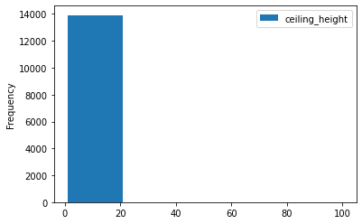

```python
df.plot(kind='hist', y='ceiling_height', bins=5)
```

```python
# Есть и выбросы значений в 100 метров высоты потолка. Используем метод describe() чтобы подробнее взглянуть
# на данные

df['ceiling_height'].describe()
```

```
count    13937.000000
mean         2.759605
std          1.265421
min          1.000000
25%          2.500000
50%          2.650000
75%          2.800000
max        100.000000
Name: ceiling_height, dtype: float64
```

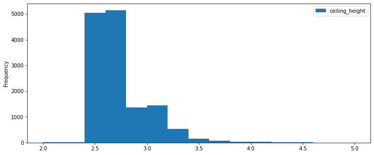

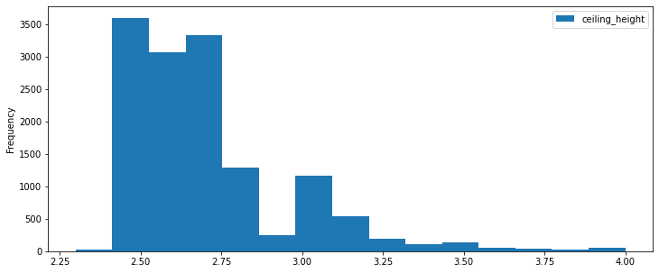

```python
# Теперь, когда мы видим значения квартилей, взглянем на ту же гистограмму, но уже в других масштабах
df.plot(kind='hist', y='ceiling_height', bins=15, range=(2, 5), figsize=(12,5))
df.plot(kind='hist', y='ceiling_height', bins=15, range=(2.3, 4), figsize=(12,5))
```

```python
median_ceiling_height = df['ceiling_height'].median() # Сохранили медиану в переменной
```

```python
# Заменим пустые значения столбца на медиану

df['ceiling_height'] = df['ceiling_height'].fillna(median_ceiling_height)
```

```python
normin = round(2.65 - (2.8 - 2.5) * 1.5, 1)
normax = round(2.65 + (2.8 - 2.5) * 1.5, 1)
```

```python
print("Минимальное допустимое значение высоты потолка:", normin)
print("Максимальное допустимое значение высоты потолка:", normax)
```

```
Минимальное допустимое значение высоты потолка: 2.2
Максимальное допустимое значение высоты потолка: 3.1
```

```python
len(df.query('ceiling_height < @normin or ceiling_height > @normax')) # Считаем число выборосов
```

```
1022
```

```python
df = df.query('ceiling_height >= @normin and ceiling_height <= @normax') # Перезаписываем таблицу, избавляемся от выбросов
```

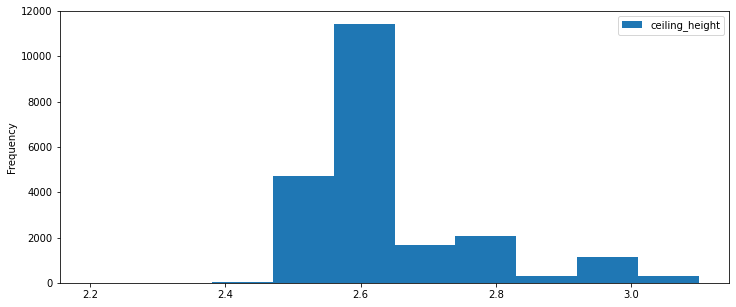

```python
df.plot(kind='hist', y='ceiling_height', bins=10, figsize=(12,5)) # Смотрим на данные столбца без выбросов
```

```python
df.isna().sum() # Оценили актуальное число пропусков в таблице
```

```
total_images                0
last_price                  0
total_area                  0
first_day_exposition        0
rooms                       0
ceiling_height              0
floors_total                0
living_area                 0
floor                       0
is_apartment                0
studio                      0
open_plan                   0
kitchen_area                0
balcony                     0
locality_name               0
airports_nearest         5209
city_centers_nearest     5190
parks_around_3000        5189
parks_nearest           14677
ponds_around_3000        5189
ponds_nearest           13657
days_exposition             0
dtype: int64
```

## Расчёты и добавление результатов в таблицу

```python
# Посчитаем и добавим в таблицу цену квадратного метра

df['square_meter_price'] = round(df['last_price'] / df['total_area'], 1)

df.head(5)
```

|  | total_images | last_price | total_area | first_day_exposition | rooms | ceiling_height | floors_total | living_area | floor | is_apartment | ... | balcony | locality_name | airports_nearest | city_centers_nearest | parks_around_3000 | parks_nearest | ponds_around_3000 | ponds_nearest | days_exposition | square_meter_price |
| --- | --- | --- | --- | --- | --- | --- | --- | --- | --- | --- | --- | --- | --- | --- | --- | --- | --- | --- | --- | --- | --- |
| 0 | 20 | 13000000 | 108.0 | 2019-03-07 | 3 | 2.70 | 16 | 51.0 | 8 | False | ... | 0 | Санкт-Петербург | 18863.0 | 16028.0 | 1.0 | 482.0 | 2.0 | 755.0 | 57 | 120370.4 |
| 1 | 7 | 3350000 | 40.4 | 2018-12-04 | 1 | 2.65 | 11 | 18.6 | 1 | False | ... | 2 | посёлок Шушары | 12817.0 | 18603.0 | 0.0 | NaN | 0.0 | NaN | 81 | 82920.8 |
| 2 | 10 | 5196000 | 56.0 | 2015-08-20 | 2 | 2.65 | 5 | 34.3 | 4 | False | ... | 0 | Санкт-Петербург | 21741.0 | 13933.0 | 1.0 | 90.0 | 2.0 | 574.0 | 558 | 92785.7 |
| 3 | 0 | 64900000 | 159.0 | 2015-07-24 | 3 | 2.65 | 14 | 89.7 | 9 | False | ... | 0 | Санкт-Петербург | 28098.0 | 6800.0 | 2.0 | 84.0 | 3.0 | 234.0 | 424 | 408176.1 |
| 4 | 2 | 10000000 | 100.0 | 2018-06-19 | 2 | 3.03 | 14 | 32.0 | 13 | False | ... | 0 | Санкт-Петербург | 31856.0 | 8098.0 | 2.0 | 112.0 | 1.0 | 48.0 | 121 | 100000.0 |

5 rows × 23 columns

```python
# Создадим столбцы, которые будет содержать информацию о дне недели, месяце и годе публикации объявления.

# Чтобы получить корректный номер дня недели, будем прибавлять число 1 к значению его индекса
from datetime import datetime

def create_weekday(row):
    weekday_index = datetime.weekday(row['first_day_exposition'])
    weekday = weekday_index + 1
    return weekday

def create_month(row):
    str_date = str(row['first_day_exposition'])
    month = str_date.split('-')[1]
    return month

def create_year(row):
    str_date = str(row['first_day_exposition'])
    year = str_date.split('-')[0]
    return year
```

```python
df['weekday'] = df.apply(create_weekday, axis=1)
df['month'] = df.apply(create_month, axis=1)
df['year'] = df.apply(create_year, axis=1)


df.head() # Убедимся, что столбцы добавлены
```

|  | total_images | last_price | total_area | first_day_exposition | rooms | ceiling_height | floors_total | living_area | floor | is_apartment | ... | city_centers_nearest | parks_around_3000 | parks_nearest | ponds_around_3000 | ponds_nearest | days_exposition | square_meter_price | weekday | month | year |
| --- | --- | --- | --- | --- | --- | --- | --- | --- | --- | --- | --- | --- | --- | --- | --- | --- | --- | --- | --- | --- | --- |
| 0 | 20 | 13000000 | 108.0 | 2019-03-07 | 3 | 2.70 | 16 | 51.0 | 8 | False | ... | 16028.0 | 1.0 | 482.0 | 2.0 | 755.0 | 57 | 120370.4 | 4 | 03 | 2019 |
| 1 | 7 | 3350000 | 40.4 | 2018-12-04 | 1 | 2.65 | 11 | 18.6 | 1 | False | ... | 18603.0 | 0.0 | NaN | 0.0 | NaN | 81 | 82920.8 | 2 | 12 | 2018 |
| 2 | 10 | 5196000 | 56.0 | 2015-08-20 | 2 | 2.65 | 5 | 34.3 | 4 | False | ... | 13933.0 | 1.0 | 90.0 | 2.0 | 574.0 | 558 | 92785.7 | 4 | 08 | 2015 |
| 3 | 0 | 64900000 | 159.0 | 2015-07-24 | 3 | 2.65 | 14 | 89.7 | 9 | False | ... | 6800.0 | 2.0 | 84.0 | 3.0 | 234.0 | 424 | 408176.1 | 5 | 07 | 2015 |
| 4 | 2 | 10000000 | 100.0 | 2018-06-19 | 2 | 3.03 | 14 | 32.0 | 13 | False | ... | 8098.0 | 2.0 | 112.0 | 1.0 | 48.0 | 121 | 100000.0 | 2 | 06 | 2018 |

5 rows × 26 columns

```python
# Добавим столбец с типом этажа квартиры; варианты — первый, последний, другой; Напишем функцию

def create_floor_type(row):
    floor = row['floor']
    floors_total = row['floors_total']
    if floor == 1: # если значение этажа равно единице (даже если это одноэтажный дом)
        return 'первый' # то этаж первый
    if floor == floors_total: # если значение этажа равно количеству этажей (кроме случая, когда первый этаж в одноэтажном доме)
        return 'последний' # то этаж последний
    return 'другой' # иначе этаж другой
```

```python
df['floor_type'] = df.apply(create_floor_type, axis=1)
df.head() # Убедимся, что столбец добавлен

# В этом месте иногда появляется Warning. В целом он не мешает работе. Не совсем понятна природа происхождения
```

|  | total_images | last_price | total_area | first_day_exposition | rooms | ceiling_height | floors_total | living_area | floor | is_apartment | ... | parks_around_3000 | parks_nearest | ponds_around_3000 | ponds_nearest | days_exposition | square_meter_price | weekday | month | year | floor_type |
| --- | --- | --- | --- | --- | --- | --- | --- | --- | --- | --- | --- | --- | --- | --- | --- | --- | --- | --- | --- | --- | --- |
| 0 | 20 | 13000000 | 108.0 | 2019-03-07 | 3 | 2.70 | 16 | 51.0 | 8 | False | ... | 1.0 | 482.0 | 2.0 | 755.0 | 57 | 120370.4 | 4 | 03 | 2019 | другой |
| 1 | 7 | 3350000 | 40.4 | 2018-12-04 | 1 | 2.65 | 11 | 18.6 | 1 | False | ... | 0.0 | NaN | 0.0 | NaN | 81 | 82920.8 | 2 | 12 | 2018 | первый |
| 2 | 10 | 5196000 | 56.0 | 2015-08-20 | 2 | 2.65 | 5 | 34.3 | 4 | False | ... | 1.0 | 90.0 | 2.0 | 574.0 | 558 | 92785.7 | 4 | 08 | 2015 | другой |
| 3 | 0 | 64900000 | 159.0 | 2015-07-24 | 3 | 2.65 | 14 | 89.7 | 9 | False | ... | 2.0 | 84.0 | 3.0 | 234.0 | 424 | 408176.1 | 5 | 07 | 2015 | другой |
| 4 | 2 | 10000000 | 100.0 | 2018-06-19 | 2 | 3.03 | 14 | 32.0 | 13 | False | ... | 2.0 | 112.0 | 1.0 | 48.0 | 121 | 100000.0 | 2 | 06 | 2018 | другой |

5 rows × 27 columns

```python
# Создадим столбец для значений соотношения жилой площади к общей площади

df['living_to_total_area'] = round(df['living_area'] / df['total_area'], 2)

# Создадим столбец для значений соотношения площади кухни к общей площади
df['kitchen_to_total_area'] = round(df['kitchen_area'] / df['total_area'], 2)

df.head() # Убедимся, что столбцы появились
```

|  | total_images | last_price | total_area | first_day_exposition | rooms | ceiling_height | floors_total | living_area | floor | is_apartment | ... | ponds_around_3000 | ponds_nearest | days_exposition | square_meter_price | weekday | month | year | floor_type | living_to_total_area | kitchen_to_total_area |
| --- | --- | --- | --- | --- | --- | --- | --- | --- | --- | --- | --- | --- | --- | --- | --- | --- | --- | --- | --- | --- | --- |
| 0 | 20 | 13000000 | 108.0 | 2019-03-07 | 3 | 2.70 | 16 | 51.0 | 8 | False | ... | 2.0 | 755.0 | 57 | 120370.4 | 4 | 03 | 2019 | другой | 0.47 | 0.23 |
| 1 | 7 | 3350000 | 40.4 | 2018-12-04 | 1 | 2.65 | 11 | 18.6 | 1 | False | ... | 0.0 | NaN | 81 | 82920.8 | 2 | 12 | 2018 | первый | 0.46 | 0.27 |
| 2 | 10 | 5196000 | 56.0 | 2015-08-20 | 2 | 2.65 | 5 | 34.3 | 4 | False | ... | 2.0 | 574.0 | 558 | 92785.7 | 4 | 08 | 2015 | другой | 0.61 | 0.15 |
| 3 | 0 | 64900000 | 159.0 | 2015-07-24 | 3 | 2.65 | 14 | 89.7 | 9 | False | ... | 3.0 | 234.0 | 424 | 408176.1 | 5 | 07 | 2015 | другой | 0.56 | 0.17 |
| 4 | 2 | 10000000 | 100.0 | 2018-06-19 | 2 | 3.03 | 14 | 32.0 | 13 | False | ... | 1.0 | 48.0 | 121 | 100000.0 | 2 | 06 | 2018 | другой | 0.32 | 0.41 |

5 rows × 29 columns

## Исследовательский анализ данных

Изучим следующие параметры: площадь, цена, число комнат, высота потолков. Также построим гистограммы для каждого параметра.

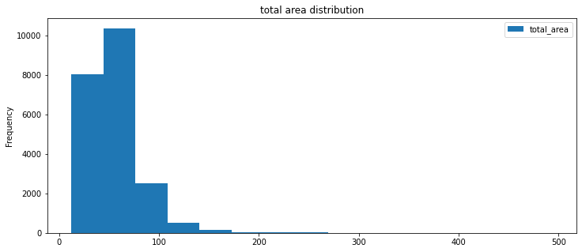

```python
# Изучим площадь и построим гистограмму по столбцу 'total_area'

df.plot(kind='hist', y='total_area', figsize=(12, 5), bins=15, title='total area distribution')
```

На гистограмме видно, что большая часть значений находится в диапазоне до 200 квадратных метров. Имеются выбросы, значения которых стремятся к 500 квадратным метрам. Изучим данные с помощью метода describe() и построим гистограмму в более подходящем для исследования масштабе.

```python
df['total_area'].describe()
```

```
count    21660.00000
mean        56.15283
std         25.02591
min         12.00000
25%         39.80000
50%         50.10000
75%         66.00000
max        494.10000
Name: total_area, dtype: float64
```

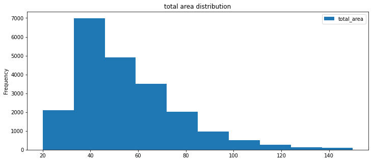

```python
df.plot(kind='hist', y='total_area', figsize=(12, 5), bins=10, range=(20, 150), title='total area distribution')
```

Распределение такой гистограммы напоминает распределение Пуассона и имеет пик в районе медианного значения, после медианного значения график идёт на спад, частота с увеличением метража объектов недвижимости затухает.

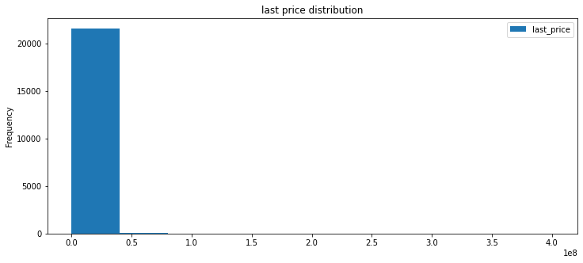

```python
# Изучим цены и построим гистограмму по столбцу 'last_price'

df.plot(kind='hist', y='last_price', figsize=(12, 5), bins=10, title='last price distribution')
```

```python
df['last_price'].describe()
```

```
count    2.166000e+04
mean     5.711100e+06
std      6.079711e+06
min      1.219000e+04
25%      3.390000e+06
50%      4.500000e+06
75%      6.300000e+06
max      4.013000e+08
Name: last_price, dtype: float64
```

Столбец 'last_price' содержит слишком большие значения, из-за чего читать гистограмму и результат вызова метода describe() с основными характеристиками столбца становится очень тяжело. Значения столбца 'last_price' будем считать в миллионах, для этого разделим значения столбца на миллион.

Это изменение не повлечёт изменения в столбце 'square_meter_price', поэтому умножать значения этого столбца на миллион мы не будем.

```python
df['last_price'] = round(df['last_price'] / 1000000, 3)
df.head() # Оценили таблицу после изменений в значении столбца 'last_price'
```

|  | total_images | last_price | total_area | first_day_exposition | rooms | ceiling_height | floors_total | living_area | floor | is_apartment | ... | ponds_around_3000 | ponds_nearest | days_exposition | square_meter_price | weekday | month | year | floor_type | living_to_total_area | kitchen_to_total_area |
| --- | --- | --- | --- | --- | --- | --- | --- | --- | --- | --- | --- | --- | --- | --- | --- | --- | --- | --- | --- | --- | --- |
| 0 | 20 | 13.000 | 108.0 | 2019-03-07 | 3 | 2.70 | 16 | 51.0 | 8 | False | ... | 2.0 | 755.0 | 57 | 120370.4 | 4 | 03 | 2019 | другой | 0.47 | 0.23 |
| 1 | 7 | 3.350 | 40.4 | 2018-12-04 | 1 | 2.65 | 11 | 18.6 | 1 | False | ... | 0.0 | NaN | 81 | 82920.8 | 2 | 12 | 2018 | первый | 0.46 | 0.27 |
| 2 | 10 | 5.196 | 56.0 | 2015-08-20 | 2 | 2.65 | 5 | 34.3 | 4 | False | ... | 2.0 | 574.0 | 558 | 92785.7 | 4 | 08 | 2015 | другой | 0.61 | 0.15 |
| 3 | 0 | 64.900 | 159.0 | 2015-07-24 | 3 | 2.65 | 14 | 89.7 | 9 | False | ... | 3.0 | 234.0 | 424 | 408176.1 | 5 | 07 | 2015 | другой | 0.56 | 0.17 |
| 4 | 2 | 10.000 | 100.0 | 2018-06-19 | 2 | 3.03 | 14 | 32.0 | 13 | False | ... | 1.0 | 48.0 | 121 | 100000.0 | 2 | 06 | 2018 | другой | 0.32 | 0.41 |

5 rows × 29 columns

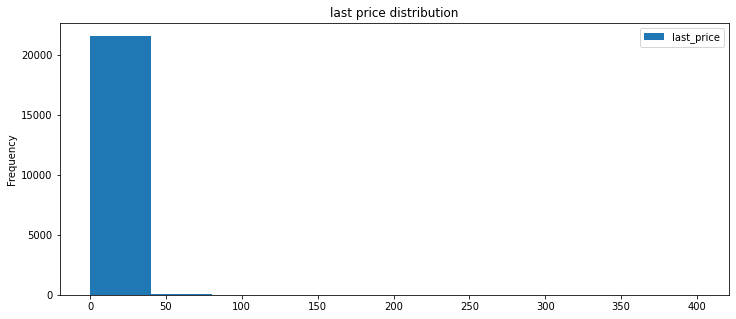

```python
df.plot(kind='hist', y='last_price', figsize=(12, 5), bins=10, title='last price distribution')
```

Теперь не сложно заметить, что основной ценовой диапазон объектов недвижимости находится до 50 миллионов. В данных имеются выбросы, значения которых достигают 400 миллионов. Чтобы разобраться лучше, используем метод describe() и масштабируем гистограмму.

```python
df['last_price'].describe()
```

```
count    21660.000000
mean         5.711100
std          6.079711
min          0.012000
25%          3.390000
50%          4.500000
75%          6.300000
max        401.300000
Name: last_price, dtype: float64
```

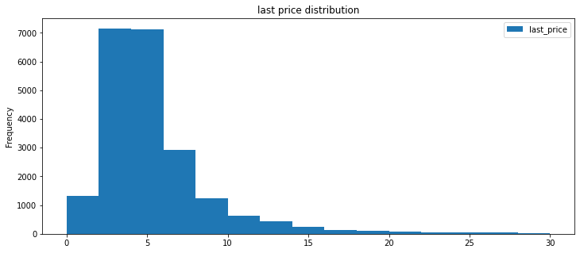

```python
df.plot(kind='hist', y='last_price', figsize=(12, 5), bins=15, range=(0, 30), title='last price distribution')
```

Такое распределение больше напоминает нормальное, чем распределение с площадью объектов недвижимости. Мы видим, что максимальная частота находится в районе медианного значения, а объекты, чья стоимость находится в диапазонах от 0 до 2 миллионов и от 8 до 10 можно встретить с примерно одинаковой частотой. У распределения длинный хвост в сторону увеличения стоимость объектов недвижимости.

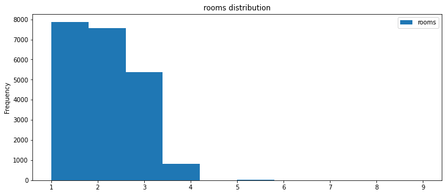

```python
# Изучим число комнат и построим гистограмму по столбцу 'rooms'
df.plot(kind='hist', y='rooms', figsize=(12, 5), bins=10, title='rooms distribution')
```

Здесь не потребуется масштабирование: всё и так предельно ясно — наиболее популярным вариантов являются однокомнатные объекты недвижимости, затем с увеличением числа комнат частота таких объектов на рынке недвижимости снижается. Распределение Пуассона. Посмотрим на результаты, которые вернёт метод describe()

```python
df['rooms'].describe()
```

```
count    21660.000000
mean         1.964266
std          0.880934
min          1.000000
25%          1.000000
50%          2.000000
75%          3.000000
max          9.000000
Name: rooms, dtype: float64
```

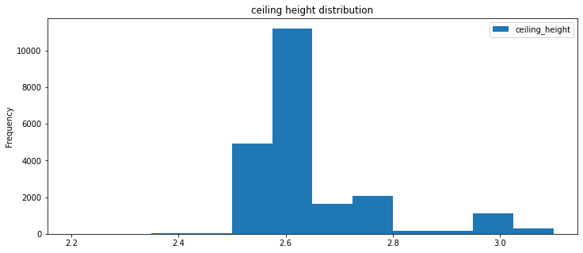

```python
# Изучим высоту потолков и построим гистограмму по столбцу 'ceiling_height'
df.plot(kind='hist', y='ceiling_height', figsize=(12, 5), bins=12, title='ceiling height distribution')
```

Так как мы удаляли выбросы из этого столбца, то помним, как распределены в нём значения после удаления выбросов: от 2.2 метров до 3.1. Пик гистограммы соответствует медианному значению. На гистограмме видно, что высота потолков от 2.8 до примерно 2.95 метров встречается реже, чем от 2.95 до 3.05.

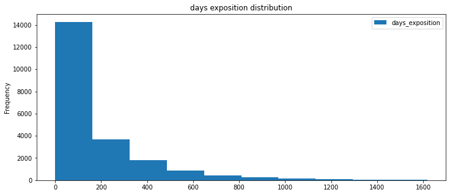

```python
# Теперь изучим время продажи квартиры. Построим гистограмму по столбцу 'days_exposition'.

df.plot(kind='hist', y='days_exposition', figsize=(12, 5), bins=10, title='days exposition distribution')
```

На гистограмме видим распределение, напоминающее распределение Пуассона: в основном чем больше значение, тем реже оно встречается. Значения распределены от нуля дней до примерно 1700. Изучим данные с помощью метода describe(), чтобы построить гистограмму в более подходящем масштабе.

```python
df['days_exposition'].describe()
```

```
count    21660.000000
mean       179.494275
std        226.691623
min          0.000000
25%         42.000000
50%         91.000000
75%        226.000000
max       1618.000000
Name: days_exposition, dtype: float64
```

На основе значений, которые расположились в межквартильном размахе, мы можем утверждать, что обычно время продажи квартиры занимает от 42 до 226 дней, то есть от полутора до семи с половиной месяцев. При этом медиана в 91 день сильно отклоняется от среднего значения в 179 дней, что говорит о наличии выбросов в данных: мы видим, что максимальное значение составляет 1618 дней. И минимальное и максимальное значения вполне могут быть правдоподобными. На гистограмме в новом масштабе рассмотрим распределение значений от 0 до 500.

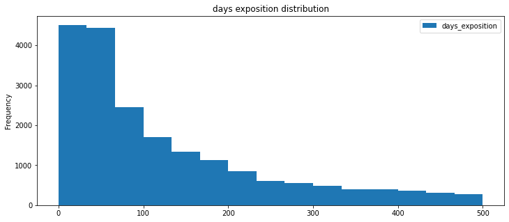

```python
df.plot(kind='hist', y='days_exposition', figsize=(12, 5), bins=15, range=(0, 500), title='days exposition distribution')
```

На такой гистограмме ярко выраженный пик в районе значения первого квартиля, что говорит о том, что действительно полтора месяца это очень популярное значение дней, прошедших от публикации объявления до продажи объекта недвижимости. Распределение ещё больше стало напоминать распределение Пуассона. Оно плавно угасает от значения первого квартиля к значению 500 дней, которое мы выбрали в качестве границы масштаба.

Пункт: Уберите редкие и выбивающиеся значения. Опишите, какие особенности обнаружили. В общем то, мы масштабировали гистограмму в самых популярных значениях и описали обнаруженные особенности :) Или имеется в виду просто удалить редкие выбивающиеся значения из столбцов таблицы на этом этапе?

Изучим, какие факторы больше всего влияют на стоимость квартиры. Выясним, зависит ли цена от площади, числа комнат, удалённости от центра, типа этажа (первый, последний, другой), а также зависимость от даты размещения: дня недели, месяца и года.

```python
# Прежде, чем строить диаграмму рассеивания, удалим очень cильные выбросы из значений столбца last_price
# Мы помним, что основные значения цен расположены в диапазоне примерно до 60 миллионов

df_for_calc = df.query('last_price <= 60')
```

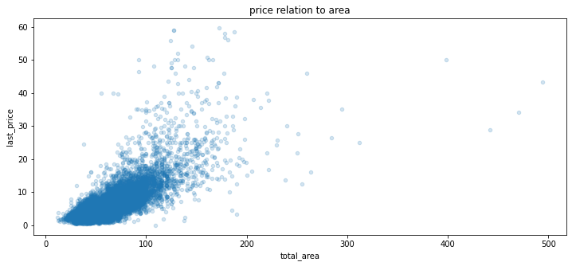

```python
# Построим диаграмму рассеивания. Зависимую переменную (стоимость объекта недвижимости) разместим на оси y.
# Независимую (площадь объекта недвижимости) — на оси x.

df_for_calc.plot(x='total_area', y='last_price', kind='scatter', alpha=0.2, figsize=(12, 5), title='price relation to area')
```

```python
# Рассчитаем коэффициент корреляции Пирсона
df_for_calc['last_price'].corr(df_for_calc['total_area'])
```

```
0.7547828958937418
```

Значение коэффициента корреляции 0.75 говорит о наличии связи между ценой объекта недвижимости и его площадью. Чем больше площадь объекта недвижимости, тем, соответственно, больше стоимость объекта.

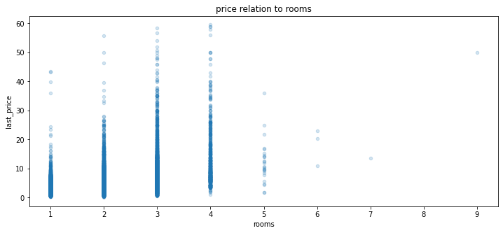

```python
# Построим диаграмму рассеивания. Зависимую переменную (стоимость объекта недвижимости) разместим на оси y.
# Независимую (число комнат) — на оси x.

df_for_calc.plot(x='rooms', y='last_price', kind='scatter', alpha=0.2, figsize=(12, 5), title='price relation to rooms')
```

Поскольку столбец со значениями количества комнат содержит дискретные значения, такая диаграмма рассеивания больше напоминает барчарт. Но и в таком виде можно сделать вывод: например, сказать, что взаимосвязь с положительной корреляцией прослеживается для объектов недвижимости, которые имеют от одной до четырёх комнат. Более верным решением будет действительно построить барчарт на основе данных из сводной таблицы, с помощью которой рассчитаем медианное значение цены для объектов недвижимости с разным числом комнат.

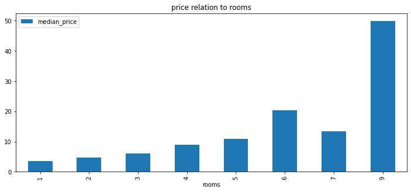

```python
price_to_rooms = df_for_calc.pivot_table(index='rooms', values='last_price', aggfunc='median')
price_to_rooms.columns = ['median_price']
price_to_rooms['rooms'] = price_to_rooms.index
price_to_rooms = price_to_rooms.reset_index(drop=True)

price_to_rooms.plot(kind='bar', x='rooms', y='median_price', figsize=(12, 5), title='price relation to rooms')
```

Благодаря барчарту мы видим, что значение медианной стоимости объектов недвижимости в основном растёт по мере того, как растёт число комнат у объектов недвижимости. Можно утверждать, что число комнат влияет на цену объекта недвижимости.

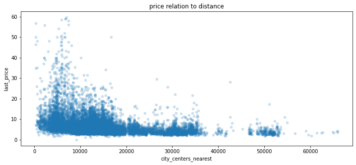

```python
# Построим диаграмму рассеивания. Зависимую переменную (стоимость объекта недвижимости) разместим на оси y.
# Независимую (значение удалённости от центра) — на оси x.

df_for_calc.plot(x='city_centers_nearest', y='last_price', kind='scatter', alpha=0.2, figsize=(12, 5), title='price relation to distance')
```

```python
df_for_calc['last_price'].corr(df_for_calc['city_centers_nearest'])
```

```
-0.3060331256382423
```

Коэффициент корреляции принял отрицательное значение, но довольно малое для того, чтобы на основании него мы утверждали о существовании взаимосвязи между удалённостью объекта недвижимости от центра и его ценой. У малого значения есть причины: мы помним, что в наших данных есть пропуски в значениях столбца удалённости от центра у объектов недвижимости, расположенных в Ленинградской области. Таких пропусков не мало и, конечно, отсутствующие значения вносят своё влияние. По графику видно, что до значения удалённости от центра города в 20000 метров или 20 км (а именно на в таком радиусе от центра расположены окраины Санкт-Петербурга) отрицательная корреляция прослеживается, затем до значения 35000 метров (35 км) значения не меняются: можно утверждать, что цены на объекты недвижимости на этом участке находятся в одном диапазоне. Кстати, именно до 35 километров расположено большинство крупных населённых пунктов, представленных в наших данных. А дальше, как уже было сказно, много пропусков. Построим диграмму рассеивания до 20 км, чтобы рассчитать коэффициент корреляции более точно.

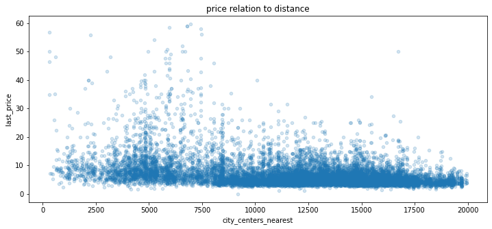

```python
df_for_calc2 = df_for_calc.query('city_centers_nearest <= 20000')
df_for_calc2.plot(x='city_centers_nearest', y='last_price', kind='scatter', alpha=0.2, figsize=(12, 5), title='price relation to distance')
```

```python
df_for_calc2['last_price'].corr(df_for_calc2['city_centers_nearest'])
```

```
-0.3719019138274935
```

Значение коэффициента корреляции по модулю действительно увеличилось, однако, теперь мы видим, что своё влияние вносят объекты недвижимости, которые расположены в радиусе 6 километров от центра. По графику кажется, что до этого значения корреляция положительная, а после — становится отрицательной. Возможно, это связано с тем, что до 6 км не так много объектов недвижимости и каждый имеет сильно отличающееся от другого значения цены. Так или иначе говорить о том, что отрицательная корреляция просеживается в некоторых диапазонах, то есть зависимость всё таки существует, мы можем.

# Изучим зависимость цены от того, на каком этаже расположен объект недвижимости: на последнем, первом или другом.

Переменная, которая хранится в значении столбца 'floor_type' является категориальной, поэтому строить диаграмму рассеивания и считать коэффициент корреляции было бы не совсем верным решением. Воспользуемся сводной таблицей и графиком барплот.

```python
price_to_floor = df_for_calc.pivot_table(index='floor_type', values='last_price', aggfunc='median').sort_values('last_price', ascending=False)
price_to_floor.columns = ['median_price']
price_to_floor['floor_type'] = price_to_floor.index
price_to_floor = price_to_floor.reset_index(drop=True)
display(price_to_floor)
```

|  | median_price | floor_type |
| --- | --- | --- |
| 0 | 4.7 | другой |
| 1 | 4.1 | последний |
| 2 | 3.8 | первый |

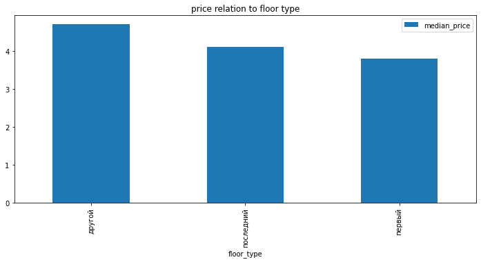

```python
price_to_floor.plot(kind='bar', x='floor_type', y='median_price', figsize=(12, 5), title='price relation to floor type')
```

Сводная таблица и график барчарт имеют понятный и удобочитаемый вид. Объекты недвижимости не на первом и не на последнем этажах стоят дороже. Дешевле всего объекты недвижимости на первом этаже.

Изучим зависимость цены от того, в какой день недели было опубликовано объявление о продаже объекта недвижимости. День недели является категориальной переменной поэтому воспользуемся сводной таблицей, чтобы оценить медианное значение цены, на объекты недвижимости, выставленные на продажу в разные дни недели.

```python
df_for_calc.pivot_table(index='weekday', values='last_price', aggfunc='median').sort_values('last_price', ascending=False)
```

| weekday | last_price |
| --- | --- |
| 2 | 4.6000 |
| 3 | 4.5500 |
| 1 | 4.5000 |
| 4 | 4.5000 |
| 7 | 4.4925 |
| 5 | 4.4890 |
| 6 | 4.4500 |

Видим отсутствие явных различий между днями недели, в которые были выставлены объекты недвижимости и их стоимостью. Объявления, размещённые во вторник имеют большее значение медианы: 4,6 миллиона. Объявления, выставленные в субботу — меньшее значение: 4.45. Различия невелики. На основе данных из сводной таблицы можем построить линейный график, чтобы увидеть как ведут себя медианные значения выставляемых объявлений о продаже недвижимости в течение недели.

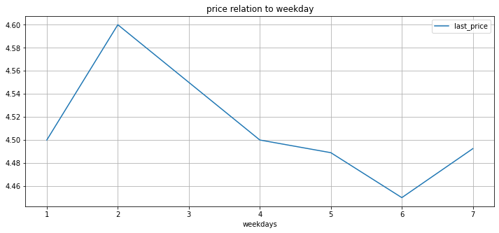

```python
weekday_distribution = df_for_calc.pivot_table(index='weekday', values='last_price', aggfunc='median').sort_values('last_price', ascending=False)
weekday_distribution['weekdays'] = weekday_distribution.index
weekday_distribution.sort_values('weekdays').plot(x='weekdays', y='last_price', figsize=(12, 5), grid=True, title='price relation to weekday')
```

Линейный график демонстрирует пик медианного значения для объявлений, которые были выставлены во вторник.

Изучим зависимость цены от того, в какой месяц было опубликовано объявление о продаже объекта недвижимости. Месяц так же является категориальной переменной, поэтому мы будем строить сводную таблицу.

```python
df_for_calc.pivot_table(index='month', values='last_price', aggfunc='median').sort_values('last_price', ascending=False)
```

| month | last_price |
| --- | --- |
| 04 | 4.680 |
| 11 | 4.599 |
| 09 | 4.550 |
| 12 | 4.550 |
| 01 | 4.500 |
| 02 | 4.500 |
| 03 | 4.500 |
| 08 | 4.500 |
| 10 | 4.500 |
| 07 | 4.450 |
| 05 | 4.430 |
| 06 | 4.250 |

О том, существует ли зависимость между месяцем публикации объявления и ценой объекта недвижимости также говорить сложно. Можем выделить апрель как месяц максимального медианного значения и такие месяцы как май, июнь и июль — в качестве месяцев с минимальными медианными значениями. На основе данных, полученных из сводной таблицы можем построить линейный график, чтобы более наглядно увидеть, как меняется медианное значение цены.

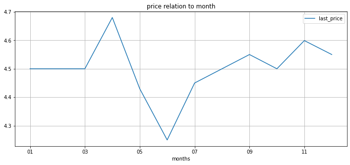

```python
month_distribution = df_for_calc.pivot_table(index='month', values='last_price', aggfunc='median').sort_values('last_price', ascending=False)
month_distribution['months'] = month_distribution.index
month_distribution.sort_values('month').plot(x='months', y='last_price', figsize=(12, 5), grid=True, title='price relation to month')
```

На таком линейном графике видны абсолютный максимум медианного значения в апреле и абсолютный минимум в июне.

Изучим зависимость цены объекта недвижимости от года размещения. Год — это тоже категориальная переменная.

```python
df_for_calc.pivot_table(index='year', values='last_price', aggfunc='median').sort_values('last_price', ascending=False)
```

| year | last_price |
| --- | --- |
| 2014 | 7.371 |
| 2015 | 5.000 |
| 2019 | 4.900 |
| 2018 | 4.500 |
| 2017 | 4.380 |
| 2016 | 4.370 |

Медианные значения стоимости объектов недвижимости за 2016 и 2017 годы — самые низкие. Взаимосвязь между стоимостью объекта недвижимости и годом, в который был выставлен этот объект так же отсутствует. Построим линейный график.

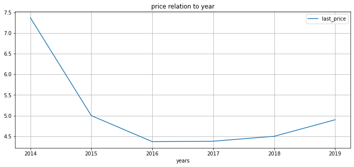

```python
year_distribution = df_for_calc.pivot_table(index='year', values='last_price', aggfunc='median').sort_values('last_price', ascending=False)
year_distribution['years'] = year_distribution.index
year_distribution.sort_values('years').plot(x='years', y='last_price', figsize=(12, 5), grid=True, title='price relation to year')
```

```python
# Выберем 10 населённых пунктов с наибольшим числом объявлений и посчитаем среднюю цену квадратного метра
popular_localities = df.pivot_table(index='locality_name', values='square_meter_price', aggfunc=['mean', 'count'])
popular_localities.columns = ['mean', 'count'] # Переименуем столбцы
# Отсортируем по количеству объявлений, выберем топ-10, после чего отсортируем по среднему значению стоимости
# квадратного метра в порядке убывания
popular_localities = popular_localities.sort_values('count', ascending=False).head(10).sort_values('mean', ascending=False)
popular_localities['locality'] = popular_localities.index # Значения индексов передадим отдельному столбцу
popular_localities = popular_localities.reset_index(drop=True) # Сбросим индексы
display(popular_localities)
```

|  | mean | count | locality |
| --- | --- | --- | --- |
| 0 | 111808.041907 | 14148 | Санкт-Петербург |
| 1 | 102370.871976 | 339 | Пушкин |
| 2 | 92297.217668 | 283 | деревня Кудрово |
| 3 | 90613.497500 | 320 | посёлок Парголово |
| 4 | 85216.549184 | 490 | посёлок Мурино |
| 5 | 78334.685412 | 425 | посёлок Шушары |
| 6 | 75948.923718 | 312 | Колпино |
| 7 | 68793.157825 | 377 | Всеволожск |
| 8 | 68462.553177 | 299 | Гатчина |
| 9 | 57724.640476 | 210 | Выборг |

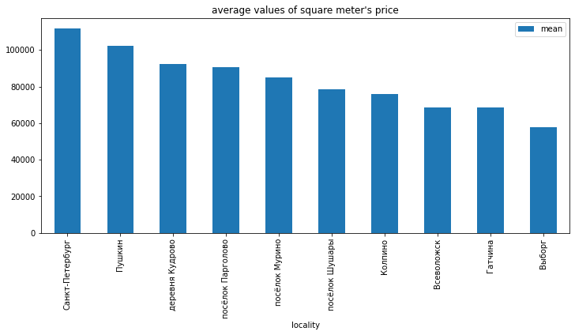

```python
popular_localities.plot(kind='bar', x='locality', y='mean', figsize=(12, 5), title="average values of square meter's price")
```

Выясним, какая область входит в центр Санкт-Петербурга. Для этого объявим отдельную таблицу, в которой будут находиться строки со значением 'Санкт-Петерубрг' в столбце 'locality_name'. Создадим для этой таблицы столбец, который будет хранить значения расстояния от центра до объектов недвижимости в километрах.

```python
spb_df = df.query('locality_name == "Санкт-Петербург"')
```

```python
spb_df['kilometers_to_center'] = spb_df['city_centers_nearest'] // 1000
```

```python
# Чтобы привести значения столбца к целому типу, убедимся, что они не содержат пропусков.
spb_df['kilometers_to_center'].isna().sum()
```

```
4
```

```python
# Удалим пропуски и приведём значения столбца к целому типу
spb_df = spb_df.dropna(subset=['kilometers_to_center'])
spb_df['kilometers_to_center'] = spb_df['kilometers_to_center'].astype('int')
```

```python
# Построим сводную таблицу, чтобы посчитать среднюю цену для каждого километра.

pivot_spb_df = spb_df.pivot_table(index='kilometers_to_center', values='last_price')
pivot_spb_df['kilometers_to_center'] = pivot_spb_df.index
pivot_spb_df = pivot_spb_df.reset_index(drop=True)
```

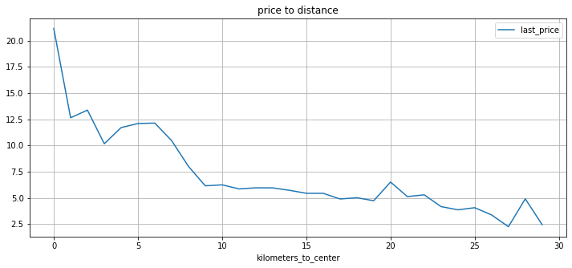

```python
# На основе сводной таблицы построим линейный график, чтобы оценить, как меняется цена по удалённости от центра

pivot_spb_df.plot(x='kilometers_to_center', y='last_price', figsize=(12, 5), grid=True, title='price to distance')
```

Линейный график показывает, что резкое падение средней цены на объекты недвижимости начинается со значения 6 километров удалённости от центра. Будем считать центром Санкт-Петербурга область в радиусе 6 километров. Выделим сегмент квартир в центре. В отдельной таблице сохраним объекты недвижимости в центре Санкт-Петербурга b проанализируем такие параметры как площадь, цена, число комнат и высота потолков.

```python
# Сохранили объекты недвижимости в центре Санкт-Петербурга в таблице center_spb_df
center_spb_df = spb_df.query('kilometers_to_center <= 6')
```

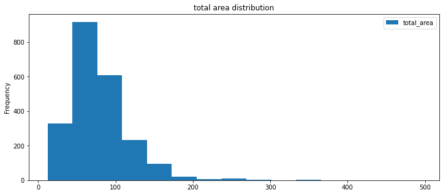

```python
# Построили гистограмму по значениям площади объектов недвижимости в центре Санкт-Петербурга в общем масштабе
center_spb_df.plot(kind='hist', y='total_area', bins=15, figsize=(12,5), title='total area distribution')
```

```python
# Изучили данные с помощью метода describe()
center_spb_df['total_area'].describe()
```

```
count    2229.000000
mean       79.188502
std        39.694459
min        12.000000
25%        52.000000
50%        71.100000
75%        95.800000
max       494.100000
Name: total_area, dtype: float64
```

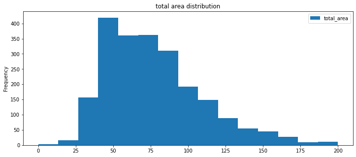

```python
center_spb_df.plot(kind='hist', y='total_area', bins=15, figsize=(12,5), range=(0, 200), title='total area distribution')
```

Распределение напоминает нормальное. Для объектов недвижимости в центре Санкт-Петербурга характерно медианное значение площади равное 71 квадратному метру. При этом первый квартиль равен 52 метрам, а третий — 95. Квартили для всех объектов недвижимости по Санкт-Петербургу и области выглядели так: 39, 50 и 66. Это говорит нам о том, что в центре Санкт-Петербурга площадь квартир значительно больше, чем по всей выборке в целом.

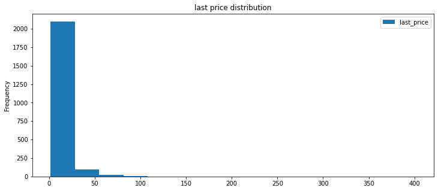

```python
# Построим гистограмму по значениям цены объектов недвижимости в центре Санкт-Петербурга в общем масштабе
center_spb_df.plot(kind='hist', y='last_price', bins=15, figsize=(12,5), title='last price distribution')
```

Основные значения стоимости объектов недвижимости в центре Санкт-Петербурга сосредоточены в диапазоне до 50 миллионов. Изучим данные столбца с помощью метода describe() и построим гистограмму в более подходящем масштабе.

```python
center_spb_df['last_price'].describe()
```

```
count    2229.000000
mean       12.006419
std        14.603704
min         1.600000
25%         6.300000
50%         8.400000
75%        12.511000
max       401.300000
Name: last_price, dtype: float64
```

Медианное значение стоимости объектов недвижимости в центре Санкт-Петербурга составляет 8.4 миллиона, первый и третий квартили равны значениям 6.3 и 12.5 миллионов соответственно. Против значений квартилей по всей выборке: 3.3, 4.5, 6.3 соответственно. Ещё раз: значение первого квартиля стоимости объектов недвижимости в центре Санкт-Петербурга равно значению третьего квартиля стоимости объектов недвижимости на всей выборке. Это говорит о том, что стоимость объектов недвижимости в центре Санкт-Петербурга значительно выше: значения квартилей почти вдвое больше, чем значения квартилей рассчитанные для всех объектов недвижимости в наших данных.

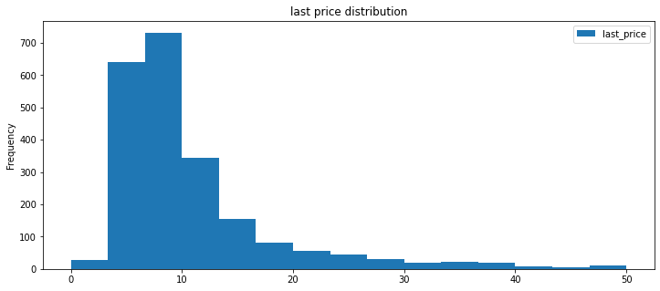

```python
center_spb_df.plot(kind='hist', y='last_price', bins=15, figsize=(12,5), range=(0, 50), title='last price distribution')
```

Здесь распределение похоже на распределение Пуассона. Мы видим, что максимум находится в районе медианного значения цены.

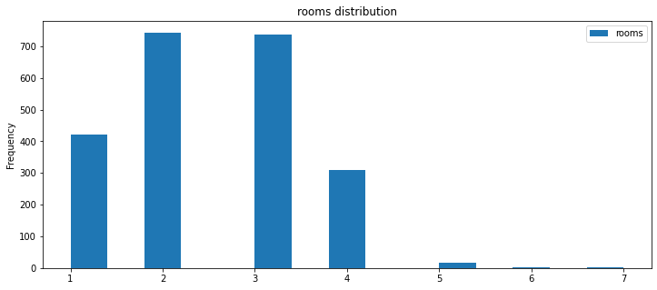

```python
# Построим гистограмму по значениям числа комнат объектов недвижимости в центре Санкт-Петербурга
center_spb_df.plot(kind='hist', y='rooms', bins=15, figsize=(12,5), title='rooms distribution')
```

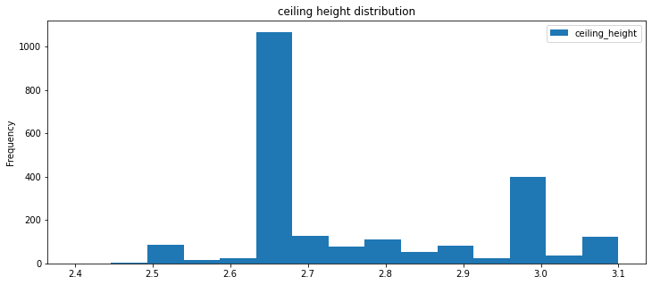

```python
# Построим гистограмму по значениям высоты потолков объектов недвижимости в центре Санкт-Петербурга
center_spb_df.plot(kind='hist', y='ceiling_height', bins=15, figsize=(12,5), title='ceiling height distribution')
```

Потолки высотой 2.65 метра по-прежнему самые популярные. Можно выделить второй по популярности высоты потолков вариант — потолки высотой в 3 метра. В прошлый раз, когда мы строили гистограмму по всем данным вторым по популярности высоты потолков вариантом у нас было значение 2.5 метра. Значит в центре Санкт-Петербурга в объектах недвижимости потолки выше.